# Exploring Red Wine Quality

Pavle Guduric

Monday, June 08, 2015

## Introduction

This project explores the quality of red wines. The analysis is based on a data set that contains different checmical and physical properties. The goal is to find the properties that influence the quality of red wines the most.

## Data Set Structure & Summary

```r
str(df)
```

```
## 'data.frame':    1599 obs. of  13 variables:
##  $ X                   : int  1 2 3 4 5 6 7 8 9 10 ...
##  $ fixed.acidity       : num  7.4 7.8 7.8 11.2 7.4 7.4 7.9 7.3 7.8 7.5 ...
##  $ volatile.acidity    : num  0.7 0.88 0.76 0.28 0.7 0.66 0.6 0.65 0.58 0.5 ...
##  $ citric.acid         : num  0 0 0.04 0.56 0 0 0.06 0 0.02 0.36 ...
##  $ residual.sugar      : num  1.9 2.6 2.3 1.9 1.9 1.8 1.6 1.2 2 6.1 ...
##  $ chlorides           : num  0.076 0.098 0.092 0.075 0.076 0.075 0.069 0.065 0.073 0.071 ...
##  $ free.sulfur.dioxide : num  11 25 15 17 11 13 15 15 9 17 ...
##  $ total.sulfur.dioxide: num  34 67 54 60 34 40 59 21 18 102 ...
##  $ density             : num  0.998 0.997 0.997 0.998 0.998 ...
##  $ pH                  : num  3.51 3.2 3.26 3.16 3.51 3.51 3.3 3.39 3.36 3.35 ...
##  $ sulphates           : num  0.56 0.68 0.65 0.58 0.56 0.56 0.46 0.47 0.57 0.8 ...
##  $ alcohol             : num  9.4 9.8 9.8 9.8 9.4 9.4 9.4 10 9.5 10.5 ...
##  $ quality             : int  5 5 5 6 5 5 5 7 7 5 ...
```

Data set has 1599 observations and 13 variables. Detailed description of each variable can be found [here](https://s3.amazonaws.com/udacity-hosted-downloads/ud651/wineQualityInfo.txt).

```r
summary(df)
```

```
##        X          fixed.acidity   volatile.acidity  citric.acid
##  Min.   :   1.0   Min.   : 4.60   Min.   :0.1200   Min.   :0.000
##  1st Qu.: 400.5   1st Qu.: 7.10   1st Qu.:0.3900   1st Qu.:0.090
##  Median : 800.0   Median : 7.90   Median :0.5200   Median :0.260
##  Mean   : 800.0   Mean   : 8.32   Mean   :0.5278   Mean   :0.271
##  3rd Qu.:1199.5   3rd Qu.: 9.20   3rd Qu.:0.6400   3rd Qu.:0.420
##  Max.   :1599.0   Max.   :15.90   Max.   :1.5800   Max.   :1.000
##  residual.sugar     chlorides       free.sulfur.dioxide
##  Min.   : 0.900   Min.   :0.01200   Min.   : 1.00
##  1st Qu.: 1.900   1st Qu.:0.07000   1st Qu.: 7.00
##  Median : 2.200   Median :0.07900   Median :14.00
##  Mean   : 2.539   Mean   :0.08747   Mean   :15.87
##  3rd Qu.: 2.600   3rd Qu.:0.09000   3rd Qu.:21.00
##  Max.   :15.500   Max.   :0.61100   Max.   :72.00
##  total.sulfur.dioxide    density             pH          sulphates
##  Min.   :  6.00       Min.   :0.9901   Min.   :2.740   Min.   :0.3300
##  1st Qu.: 22.00       1st Qu.:0.9956   1st Qu.:3.210   1st Qu.:0.5500
##  Median : 38.00       Median :0.9968   Median :3.310   Median :0.6200
##  Mean   : 46.47       Mean   :0.9967   Mean   :3.311   Mean   :0.6581
##  3rd Qu.: 62.00       3rd Qu.:0.9978   3rd Qu.:3.400   3rd Qu.:0.7300
##  Max.   :289.00       Max.   :1.0037   Max.   :4.010   Max.   :2.0000
##     alcohol         quality
##  Min.   : 8.40   Min.   :3.000
##  1st Qu.: 9.50   1st Qu.:5.000
##  Median :10.20   Median :6.000
##  Mean   :10.42   Mean   :5.636
##  3rd Qu.:11.10   3rd Qu.:6.000
##  Max.   :14.90   Max.   :8.000
```

From the summary we can see few interesting facts. `quality` is a categorical, discrete variable. It has median 6 with minimum 3 and maximum 8 - maybe it has normal distribution. According to the [description](https://s3.amazonaws.com/udacity-hosted-downloads/ud651/wineQualityInfo.txt) of our data set 0 and 10 are also possible, however no wine has this quality rating. Maximal `pH` value is 4.01 which means that all wines are acid. Maximum amount of `total.sulfur.dioxide` is 289.0 (mg/dm^3) which is by 129 (mg/dm^3) more than [currently allowed](http://www.morethanorganic.com/sulphur-in-the-bottle) by european laws for red wines. Maximal amount of `residual.sugar` is 15 (g/dm^3). According to this Wikipedia [article](http://en.wikipedia.org/wiki/Sweetness_of_wine) it seems that we are not dealing with sweet wines in our data set. `X` variable is just an id of a row.

## Univariate Analysis

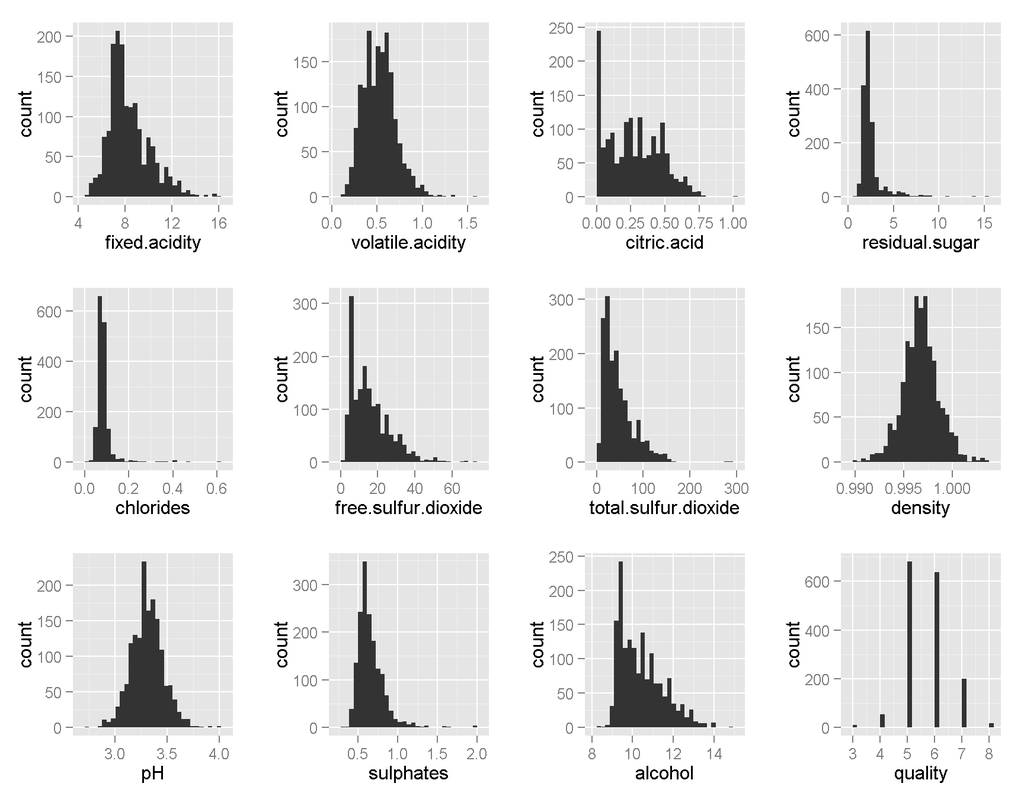

Most of the wines have quality rating 5 or 6. Although it looked like quality has normal distribution, Shapiro test confirmed it has not:

```
## $p.value
## [1] 9.515085e-36
```

I will add new categorical variable (`rating`) for quality with three groups: low, medium and high. The fact that there are 6 different ratings in the data set, makes it easier to create three different groups where each group containts two different ratings. By doing so I am able to tell whether wine is just good or bad, and everything in between is medium. Histogram for `rating` looks like this:

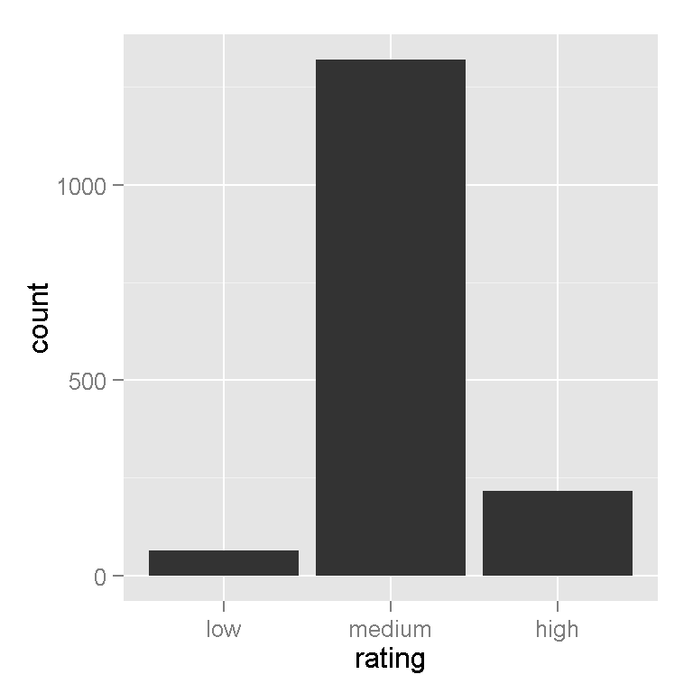

It looks like that `density` and `pH` have normal distribution. I am going to skip a test this time since it is not relevant and I am just going to stick to histograms.

```
##    Min. 1st Qu.  Median    Mean 3rd Qu.    Max.
##   2.740   3.210   3.310   3.311   3.400   4.010
```

The lowest `pH` value is 2.740 and the max is 4.010.

```
##    Min. 1st Qu.  Median    Mean 3rd Qu.    Max.
##  0.9901  0.9956  0.9968  0.9967  0.9978  1.0040
```

The lowest `density` value is 0.9901 and the max is 1.004.

According to [morethanorganic](http://www.morethanorganic.com/sulphur-in-the-bottle) a good wine has high free to bound sulfur ratio. To visualize this I will create a new variable sulfur.ratio:

```
##    Min. 1st Qu.  Median    Mean 3rd Qu.    Max.
## 0.02273 0.25930 0.37500 0.38230 0.48480 0.85710
```

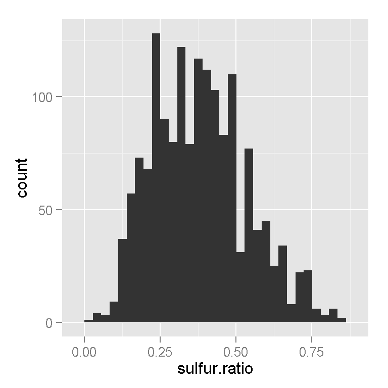

According to the same source, the ratio is 50% at best. From the summary we see that only a quarter of the observed wines are above. Quoting the same source: “For an experienced taster, accustomed to natural wine, sulphur dioxide becomes unpleasant at concentrations of around 20-30 mg/l, depending on the style of wine and the ratio of free to bound sulphur.” From the histogram for `free.sulfur.dioxide` we see that many of the observed wines are below the threshold of 20 mg/l. It would be interesting to see plot `free.sulfur.dioxide` to quality for the wines with more than 20 mg/l. The web site also provides a table for allowed amount of sulfure pro liter and majority of wines are below the allowed 160 mg/l according to the european law. Sulphur dioxide contributes significantly to hangovers. Heavy drinkers who also have to get up in the morning would be advised to stick to natural wine :)

`chlorides` have long positive tail. Outliers are better presented with a box plot:

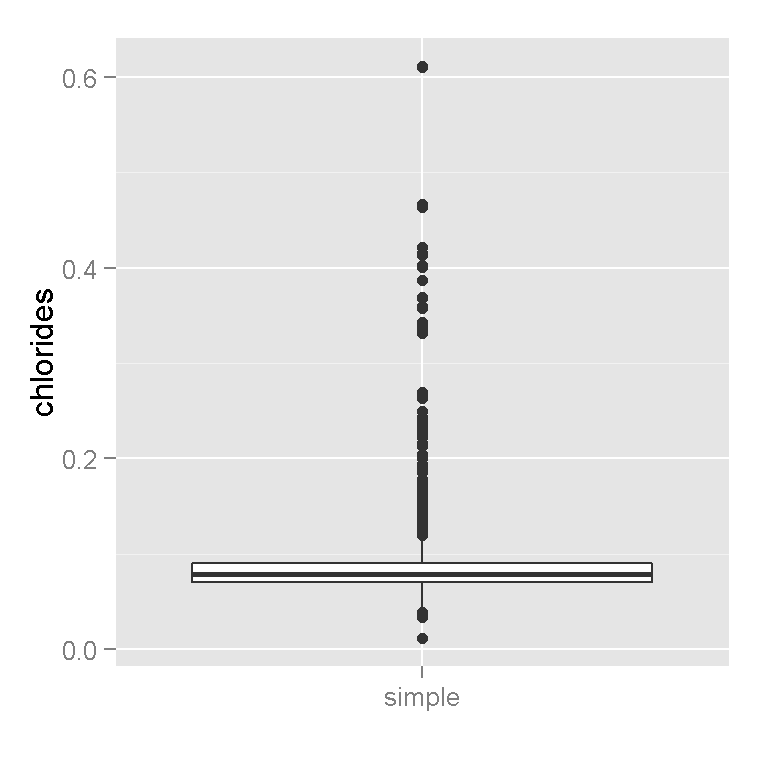

The peak for `chlorides` is between 0.07 and 0.08:

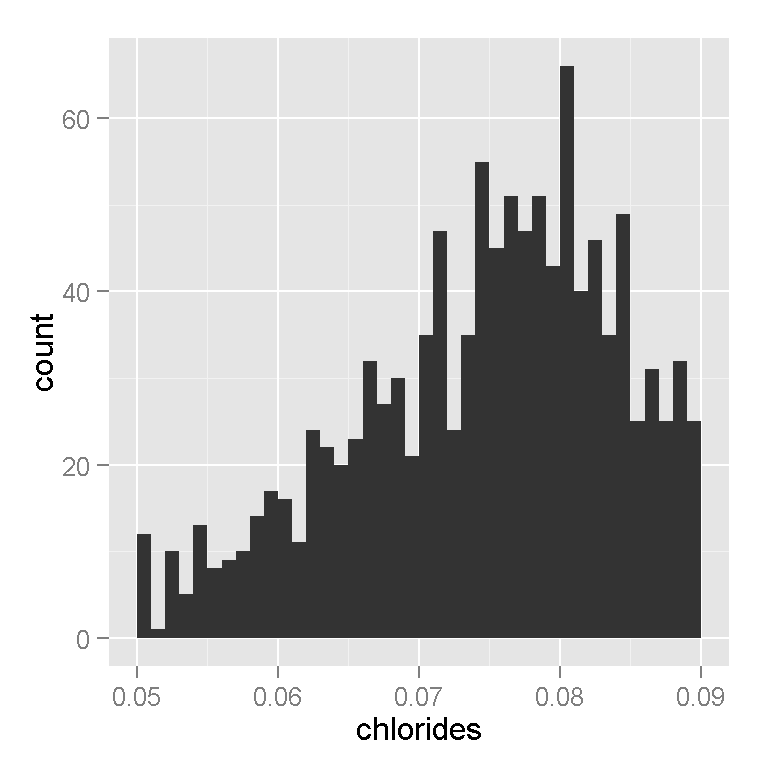

I’ll try to cut off the outliers and see if there is any significant change:

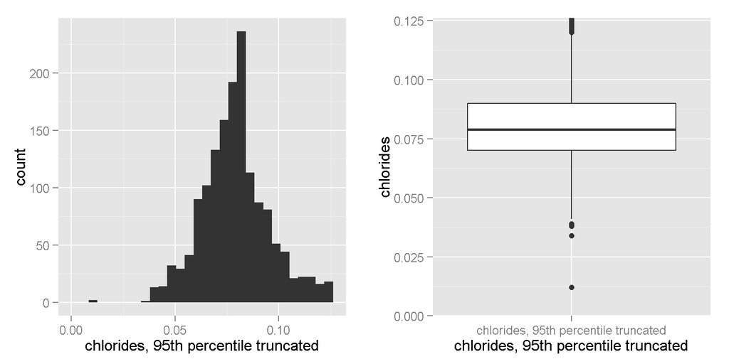

The histogram looks more normal now. According to [scielo](http://www.scielo.br/scielo.php?pid=S0101-20612015000100095&script=sci_arttext) higher levels of chlorides make wine more salty. This is heavily dependant on the grape, soil and country where the wine is produced. According to the same source the median of chlorides presented here is very low:

```
##    Min. 1st Qu.  Median    Mean 3rd Qu.    Max.
## 0.01200 0.07000 0.07900 0.08747 0.09000 0.61100
```

For example in Brazil 0.20 g/dm^3 is allowed and in Australia 0.6 g/dm^3.

`residual.sugar` has long right tail as well. After cutting off outliers:

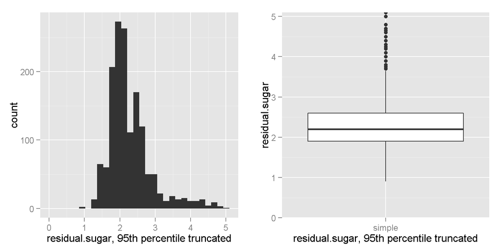

The peak for `residual.sugar` is arround 2 g/dm^3:

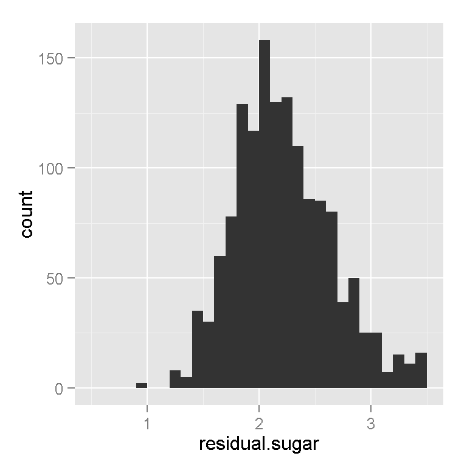

According to [Wikipedia](http://en.wikipedia.org/wiki/Sweetness_of_wine) wines with no added sugar have 0-3 g/l and sweet wines are with more than 30g/l. According to [jancisrobinson](http://www.jancisrobinson.com/articles/wines-that-are-medium) some low quality wines high with acides are added sugar to cover this. Check sugar-acidity-quality.

```
##    Min. 1st Qu.  Median    Mean 3rd Qu.    Max.
##   0.900   1.900   2.200   2.539   2.600  15.500
```

`alcohol` does not seem to have lot of outliers with most of the wines having between 9 and 12.5 % of alcohol:

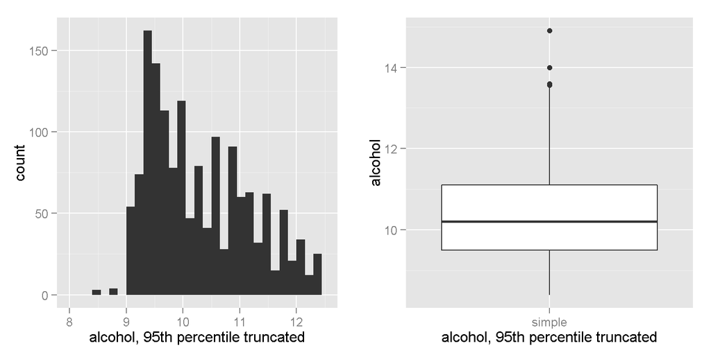

`fixed.acidity` and `volatile.acidity` transformed by log10 scale appear to be normally distributed:

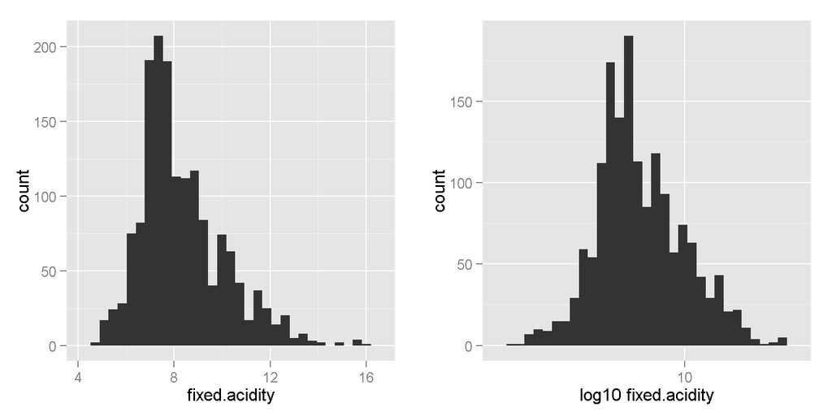

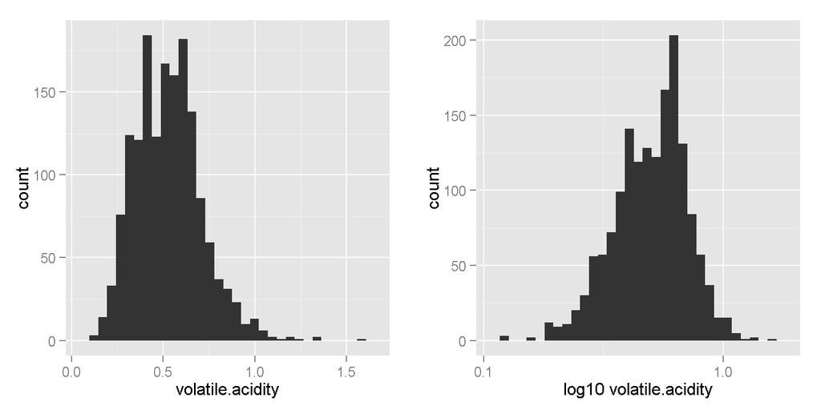

## Bivariate Analysis

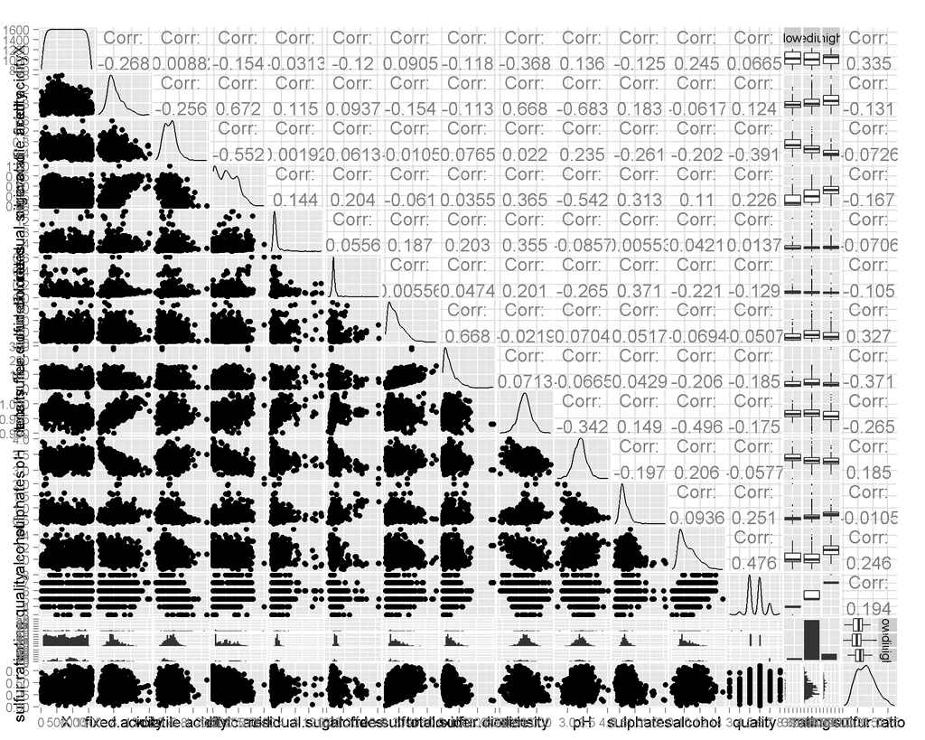

Following variables have clear effect on wine quality: `alcohol` (0.476), `sulphates` (0.251), `citric.acid` (0.226), `volatile.acidity` (-0.391) and `fixed.acidity` (0.124).

Generally following positive effects on quality can be observed:

- higher fixed acidity
- more citric acid
- lower volatile acidity
- lower pH
- higher alcohol
- higher sulphates
- lower chlorides

These are more obvious relations to wine quality. But what about with `sulfur.ratio`? Remember, good wines have free to total ratio of about 50%.

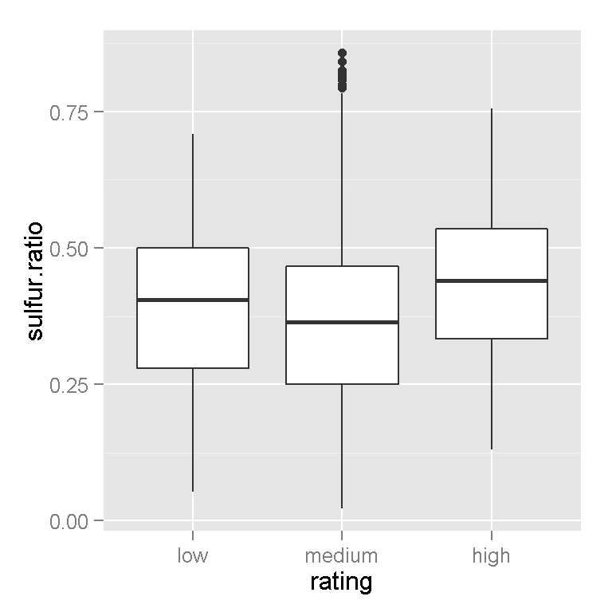

Now lets see what about salty wines and quality:

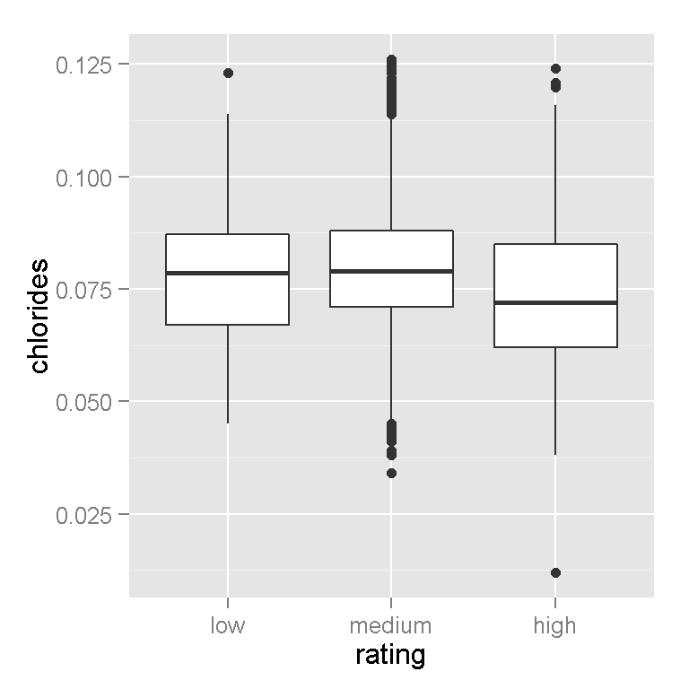

It looks like there is no difference between low and medium quality wines. The situation with high quality wine is different and it is obvious that less chlorides has positive effect on wine quality.

What about alcohol:

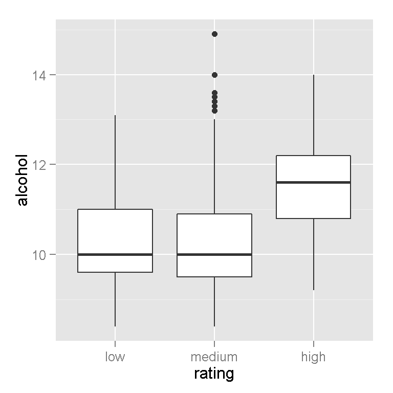

The effect of `alcohol` on quality is obvious and its correlation 0.476 stronger than other variables.

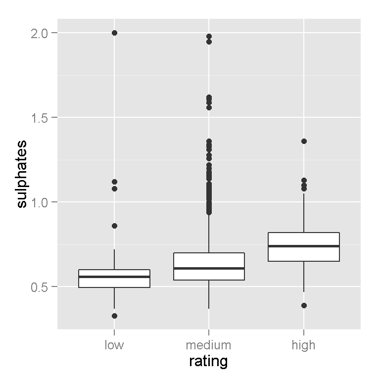

Higher amount of sulphates influences quality positivley.

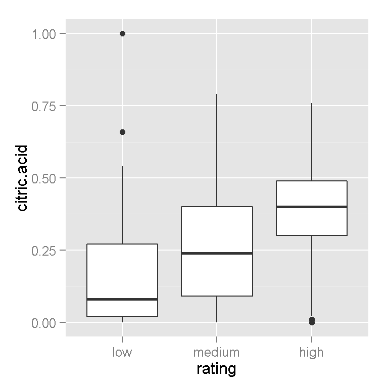

Higher amount of citric acid influences quality positivley.

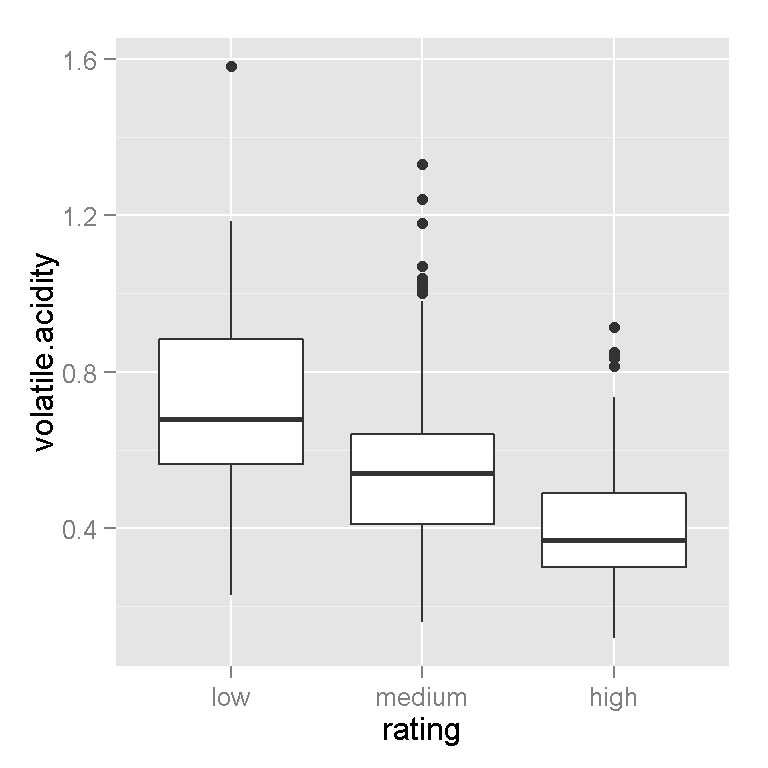

Volatile acidity has negative correlation with quality.

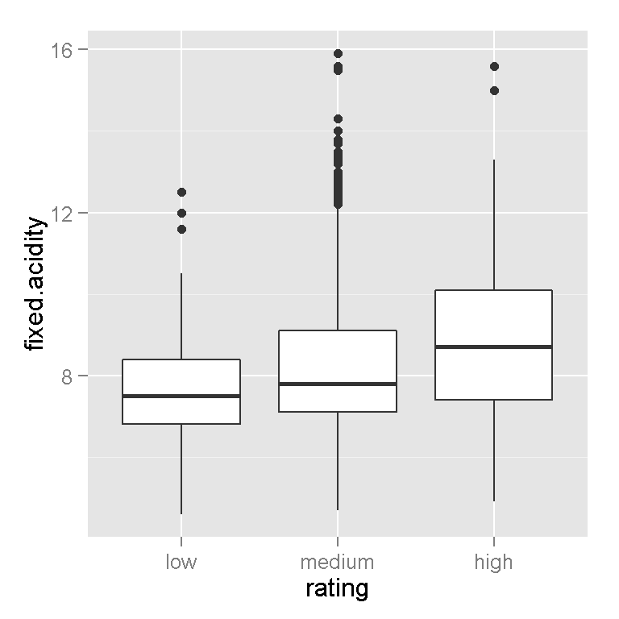

`fixed.acidity` has positive correlation with quality.

It seems that acidity of wine plays a great role in wine quality. Remember the summary for pH values. The maximum was 4.01 meaning that all wines are acid. `volatile.acidity` influences wine quality very negativly as described [here](http://waterhouse.ucdavis.edu/whats-in-wine/volatile-acidity).

## Multivariate Analysis

Let’s test the previous hypothesis: “Is there more sugar in lower quality wines characterized with higher level of acidity”:

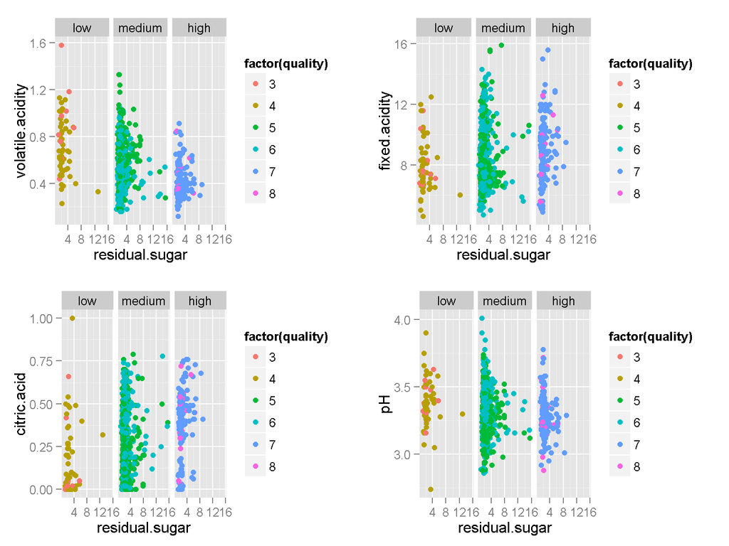

I cannot see any trend of making acid wines less acid with higher levels of sugar.

Maybe hiding saltiness with extra sugar:

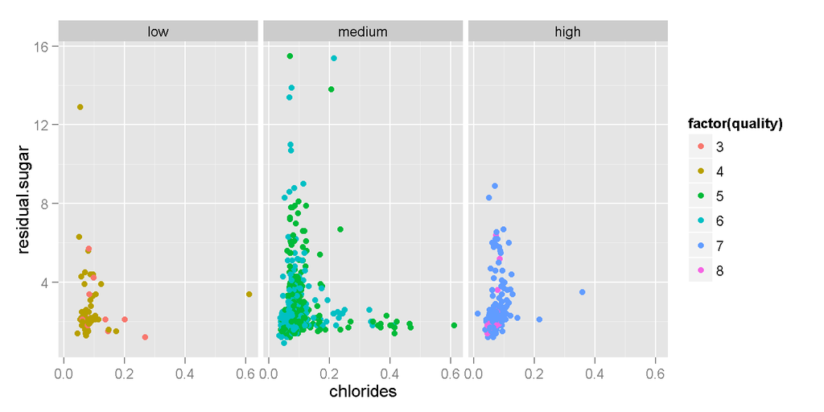

Hiding chlorides with higher levels of sugar seems not to be the case with wines in this data set. `residual.sugar` does not seem to have special correlation with other variables. Slightly higher correlation with `density` but it does not seem to affects quality:

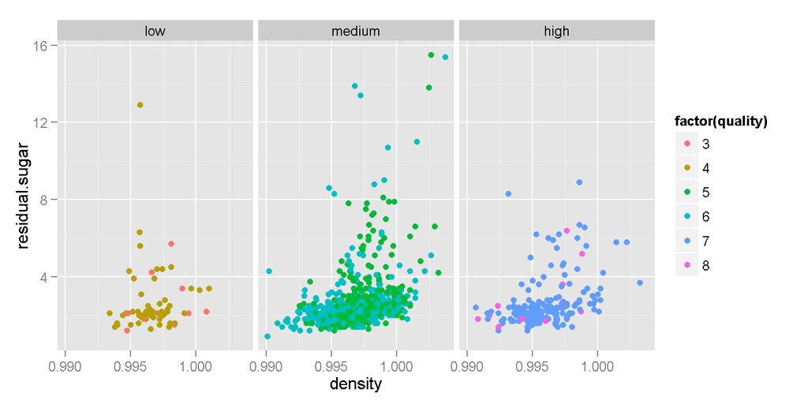

Let’s see what is the connection of `sulfur.ratio` and `alcohol` with quality:

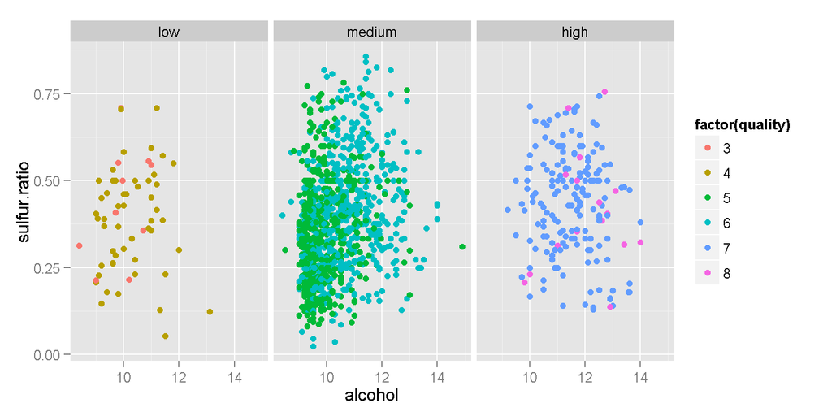

Difference between low and high quality wines is notable. Higher quality wines have `alcohol` levels between 10 and 14 and lower between 9 and 12. Many high quality wines have `sulfur.ratio` over 50% and very few of lower quality are above this treshold.

## Final Plots

### Wine Quality

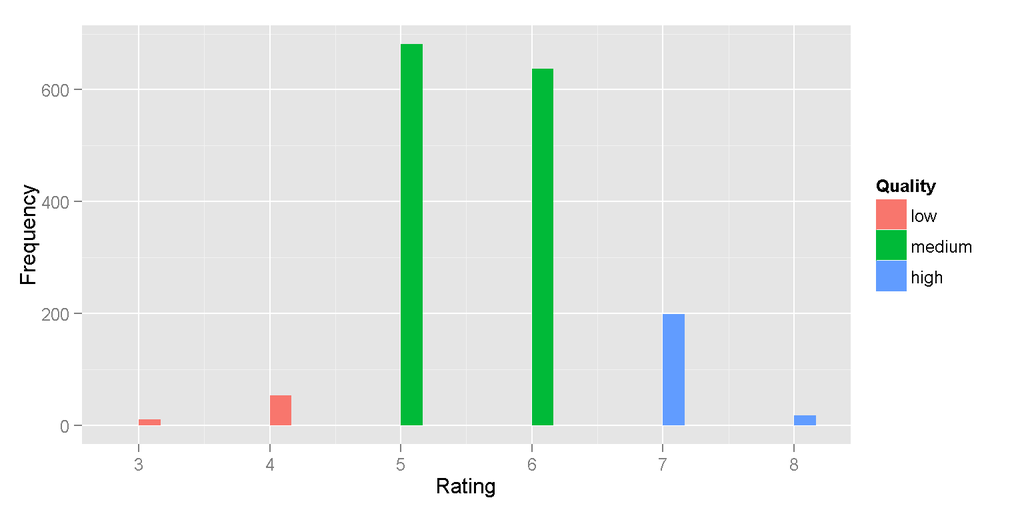

Most of the wines are of medium quality. There are more higher quality wines than lower quality wines.

### Influence of Alcohol on Quality

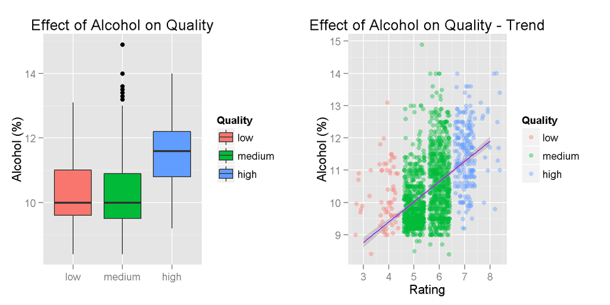

The boxplots show the effect of alcohol level on wine quality. Higher alcohol level correlates with higher wine quality. Smoothed conditional mean shows the clear trend.

### Sulfur Ratio and wine Quality

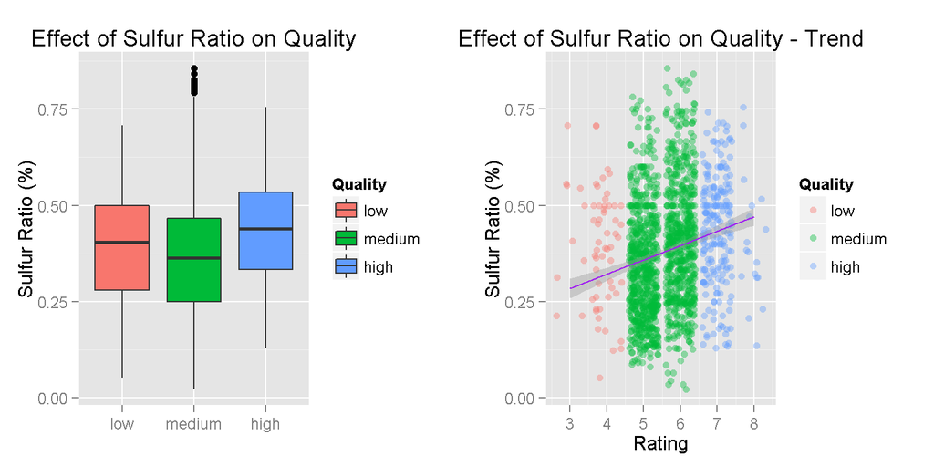

The less obvious relation between `sulfur.ratio` and `quality` shows the positive effect on quality as well.

### Acidity and Wine Quality

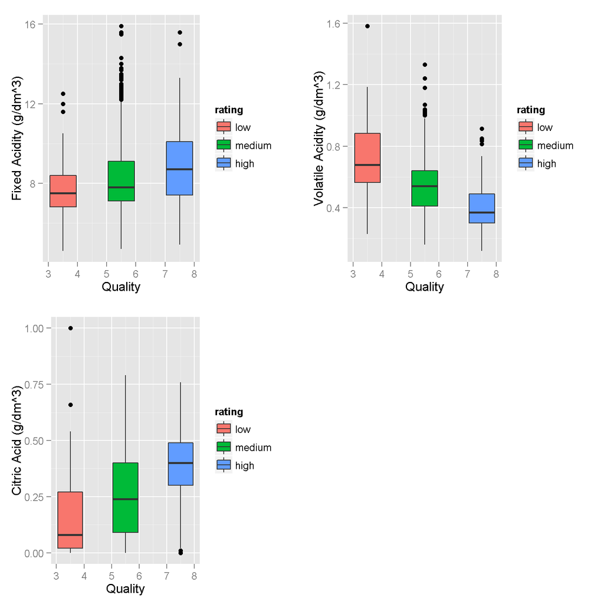

Generally, higher acidity is the property of high quality wines. Citric acid and fixed acidity showed positive effect on wine quality. Exception is volatile acidity which correlates negatively with the quality.

### Low vs. High Quality

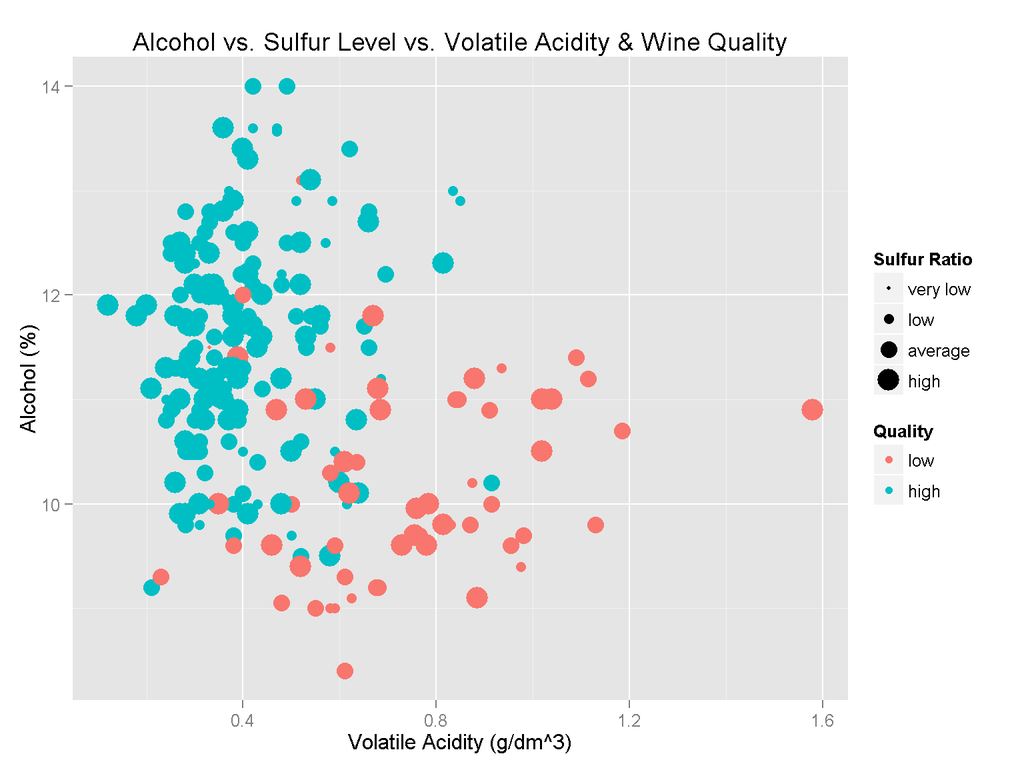

This chart summarizes the the effects of alcohol, volatile acidity and sulfur levels on wine quality. `alcohol`, as the most prominent, and `sulfur.ratio`, as not so obvious, are important contributors to high quality of wines. On the other side, `volatile.acidity`, one of the main antagonists to a real wine hedonist.

## Reflection

It is difficult to analyse data that you do not understand well. Even if you recognize certain trends and correlations between variables the “why” question remains. Reading about chemical and physical properties helped me understand better what influences wine quality. By doing so I was able to derive new variable `sulfur.ratio`. I was able to identify primary factors that determine the wine quality. Those are alcohol and sulfur level, together with acidity.

Wines included into this data set are variants of Portuguese “Vinho Verde”. As a region is important part of wine individual character, adding red wines from other regions would add to diversity of the underlying data set. Extending the data set with additional wines with certain characteristics may improve result of the analysis. For example, very few wines have more than 100mg/dm^3 of chlorides. Red wines are not generally sweet, but maybe adding some sweeter wines might reveal more about effect of sugar on quality. Also, interessting study would be to analyse the relationship between price and quality of wine.